# Course project 2 - Report

Pepe Zamarripa

2023-06-09

# The effect of weather conditions on fatalities, injuries, property and crop.

This is a report that analyzes which are the weather event types. The report is divided in two, the first part compares which are the weather event types that have a larger impact on fatal and injury events. The second part compares which are the weather event types that have a larger impact on property and crop damages.

To perform the analysis, I have used a storm database coming from the U.S. National Oceanic and Atmospheric Adminstration (NOAA).

## Data Processing

The data come in the form of a comma-separated-value file compressed using the bzip2 algorithm. Therefore, the steps to read the file are:

```r
# stormDB saves the data frame that was downloaded from a link that was provided by the course webpage
stormDB <- data.table::fread(input = "repdata_data_StormData.csv.bz2")
```

The packages needed to run the analysis are:

```r
library(plyr)
library(ggplot2)
library(gridExtra)
```

## Data Discovery

Teh database provided by NOAA has the following elements:

```r
summary(stormDB)
```

```
##     STATE__       BGN_DATE           BGN_TIME          TIME_ZONE
##  Min.   : 1.0   Length:902297      Length:902297      Length:902297
##  1st Qu.:19.0   Class :character   Class :character   Class :character
##  Median :30.0   Mode  :character   Mode  :character   Mode  :character
##  Mean   :31.2
##  3rd Qu.:45.0
##  Max.   :95.0
##
##      COUNTY       COUNTYNAME           STATE              EVTYPE
##  Min.   :  0.0   Length:902297      Length:902297      Length:902297
##  1st Qu.: 31.0   Class :character   Class :character   Class :character
##  Median : 75.0   Mode  :character   Mode  :character   Mode  :character
##  Mean   :100.6
##  3rd Qu.:131.0
##  Max.   :873.0
##
##    BGN_RANGE          BGN_AZI           BGN_LOCATI          END_DATE
##  Min.   :   0.000   Length:902297      Length:902297      Length:902297
##  1st Qu.:   0.000   Class :character   Class :character   Class :character
##  Median :   0.000   Mode  :character   Mode  :character   Mode  :character
##  Mean   :   1.484
##  3rd Qu.:   1.000
##  Max.   :3749.000
##
##    END_TIME           COUNTY_END COUNTYENDN       END_RANGE
##  Length:902297      Min.   :0    Mode:logical   Min.   :  0.0000
##  Class :character   1st Qu.:0    NA's:902297    1st Qu.:  0.0000
##  Mode  :character   Median :0                   Median :  0.0000
##                     Mean   :0                   Mean   :  0.9862
##                     3rd Qu.:0                   3rd Qu.:  0.0000
##                     Max.   :0                   Max.   :925.0000
##
##    END_AZI           END_LOCATI            LENGTH              WIDTH
##  Length:902297      Length:902297      Min.   :   0.0000   Min.   :   0.000
##  Class :character   Class :character   1st Qu.:   0.0000   1st Qu.:   0.000
##  Mode  :character   Mode  :character   Median :   0.0000   Median :   0.000
##                                        Mean   :   0.2301   Mean   :   7.503
##                                        3rd Qu.:   0.0000   3rd Qu.:   0.000
##                                        Max.   :2315.0000   Max.   :4400.000
##
```

[output cut: 25 more lines]

```
##  Min.   :-14451   Min.   :   0   Min.   :-14455   Length:902297
##  1st Qu.:  7247   1st Qu.:   0   1st Qu.:     0   Class :character
##  Median :  8707   Median :   0   Median :     0   Mode  :character
##  Mean   :  6940   Mean   :1452   Mean   :  3509
##  3rd Qu.:  9605   3rd Qu.:3549   3rd Qu.:  8735
##  Max.   : 17124   Max.   :9706   Max.   :106220
##                   NA's   :40
##      REFNUM
##  Min.   :     1
##  1st Qu.:225575
##  Median :451149
##  Mean   :451149
##  3rd Qu.:676723
##  Max.   :902297
##
```

## Analysis

The first question that we want to answer is to know which are the weather event types that affect more the security of the population. For this purpose, I analysed which are the weather event types that create more **mortality** in the population:

```r
fatality <- aggregate(FATALITIES ~ EVTYPE, data = stormDB, FUN = "sum")
fatality <- arrange(fatality, desc(fatality[, 2]))
top10fatality <- fatality[1:10,]
head(top10fatality)
```

```
##           EVTYPE FATALITIES
## 1        TORNADO       5633
## 2 EXCESSIVE HEAT       1903
## 3    FLASH FLOOD        978
## 4           HEAT        937
## 5      LIGHTNING        816
## 6      TSTM WIND        504
```

And the following weather events create more injuries in the population:

```r
injury <- aggregate(INJURIES ~ EVTYPE, data = stormDB, FUN=sum)
injury <- arrange(injury, desc(injury[, 2]))
top10injury <- injury[1:10,]
head(top10injury)
```

```
##           EVTYPE INJURIES
## 1        TORNADO    91346
## 2      TSTM WIND     6957
## 3          FLOOD     6789
## 4 EXCESSIVE HEAT     6525
## 5      LIGHTNING     5230
## 6           HEAT     2100
```

The comparison of the impact of both weather event types is:

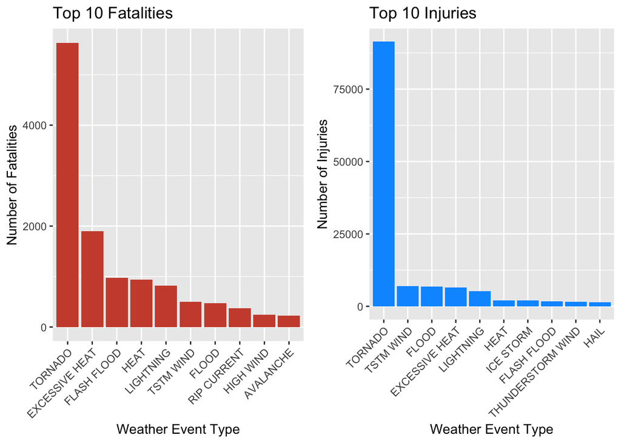

```r
# Create the fatal events chart
fatalityPlot <- ggplot(top10fatality, aes(x = reorder(EVTYPE, -FATALITIES), y = FATALITIES)) +
  geom_bar(stat = "identity", fill = "Tomato3") +
  xlab("Weather Event Type") +
  ylab("Number of Fatalities") +
  theme(axis.text.x = element_text(angle = 45, hjust = 1)) +
  ggtitle('Top 10 Fatalities')


# Create the injury events chart
injuryPlot <- ggplot(top10injury, aes(x = reorder(EVTYPE, -INJURIES), y = INJURIES)) +
  geom_bar(stat = "identity", fill = "#0099FF") +
  xlab("Weather Event Type") +
  ylab("Number of Injuries") +
  theme(axis.text.x = element_text(angle = 45, hjust = 1)) +
  ggtitle('Top 10 Injuries')


# Plot the fatal and injury charts
grid.arrange(fatalityPlot, injuryPlot, nrow = 1)
```